# Exploratory Data Analysis with R

## By Jason Zmudka

========================================================

This report analyzes a data set of 4898 white wines. Each wine’s quality was rated by a taster on a scale of 1 to 10. There are also 11 different chemical properties that were measured.

```
## 'data.frame':    4898 obs. of  13 variables:
##  $ X                   : int  1 2 3 4 5 6 7 8 9 10 ...
##  $ fixed.acidity       : num  7 6.3 8.1 7.2 7.2 8.1 6.2 7 6.3 8.1 ...
##  $ volatile.acidity    : num  0.27 0.3 0.28 0.23 0.23 0.28 0.32 0.27 0.3 0.22 ...
##  $ citric.acid         : num  0.36 0.34 0.4 0.32 0.32 0.4 0.16 0.36 0.34 0.43 ...
##  $ residual.sugar      : num  20.7 1.6 6.9 8.5 8.5 6.9 7 20.7 1.6 1.5 ...
##  $ chlorides           : num  0.045 0.049 0.05 0.058 0.058 0.05 0.045 0.045 0.049 0.044 ...
##  $ free.sulfur.dioxide : num  45 14 30 47 47 30 30 45 14 28 ...
##  $ total.sulfur.dioxide: num  170 132 97 186 186 97 136 170 132 129 ...
##  $ density             : num  1.001 0.994 0.995 0.996 0.996 ...
##  $ pH                  : num  3 3.3 3.26 3.19 3.19 3.26 3.18 3 3.3 3.22 ...
##  $ sulphates           : num  0.45 0.49 0.44 0.4 0.4 0.44 0.47 0.45 0.49 0.45 ...
##  $ alcohol             : num  8.8 9.5 10.1 9.9 9.9 10.1 9.6 8.8 9.5 11 ...
##  $ quality             : int  6 6 6 6 6 6 6 6 6 6 ...
```

```
##        X        fixed.acidity    volatile.acidity  citric.acid
##  Min.   :   1   Min.   : 3.800   Min.   :0.0800   Min.   :0.0000
##  1st Qu.:1225   1st Qu.: 6.300   1st Qu.:0.2100   1st Qu.:0.2700
##  Median :2450   Median : 6.800   Median :0.2600   Median :0.3200
##  Mean   :2450   Mean   : 6.855   Mean   :0.2782   Mean   :0.3342
##  3rd Qu.:3674   3rd Qu.: 7.300   3rd Qu.:0.3200   3rd Qu.:0.3900
##  Max.   :4898   Max.   :14.200   Max.   :1.1000   Max.   :1.6600
##  residual.sugar     chlorides       free.sulfur.dioxide total.sulfur.dioxide
##  Min.   : 0.600   Min.   :0.00900   Min.   :  2.00      Min.   :  9.0
##  1st Qu.: 1.700   1st Qu.:0.03600   1st Qu.: 23.00      1st Qu.:108.0
##  Median : 5.200   Median :0.04300   Median : 34.00      Median :134.0
##  Mean   : 6.391   Mean   :0.04577   Mean   : 35.31      Mean   :138.4
##  3rd Qu.: 9.900   3rd Qu.:0.05000   3rd Qu.: 46.00      3rd Qu.:167.0
##  Max.   :65.800   Max.   :0.34600   Max.   :289.00      Max.   :440.0
##     density             pH          sulphates         alcohol
##  Min.   :0.9871   Min.   :2.720   Min.   :0.2200   Min.   : 8.00
##  1st Qu.:0.9917   1st Qu.:3.090   1st Qu.:0.4100   1st Qu.: 9.50
##  Median :0.9937   Median :3.180   Median :0.4700   Median :10.40
##  Mean   :0.9940   Mean   :3.188   Mean   :0.4898   Mean   :10.51
##  3rd Qu.:0.9961   3rd Qu.:3.280   3rd Qu.:0.5500   3rd Qu.:11.40
##  Max.   :1.0390   Max.   :3.820   Max.   :1.0800   Max.   :14.20
##     quality
##  Min.   :3.000
##  1st Qu.:5.000
##  Median :6.000
##  Mean   :5.878
##  3rd Qu.:6.000
##  Max.   :9.000
```

In the data, there are 4898 separate observations and 12 Variables.

# Univariate Plots Section

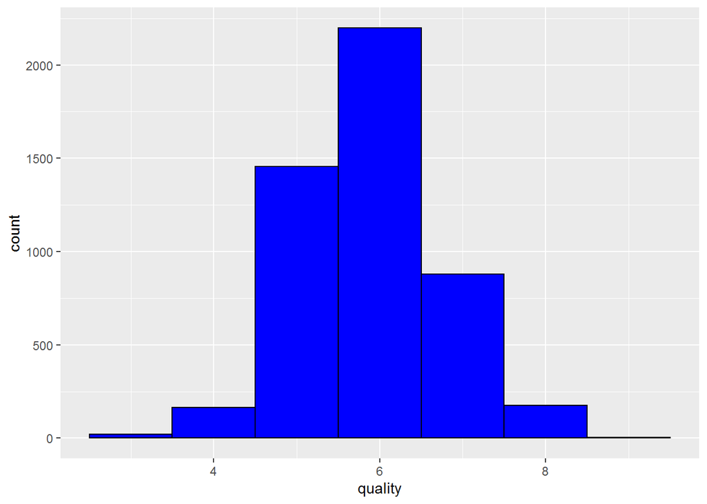

```
##    Min. 1st Qu.  Median    Mean 3rd Qu.    Max.
##   3.000   5.000   6.000   5.878   6.000   9.000
```

The quality factor gives us this normal looking histogram. The majority of wines have a quality rating of 5 or 6.

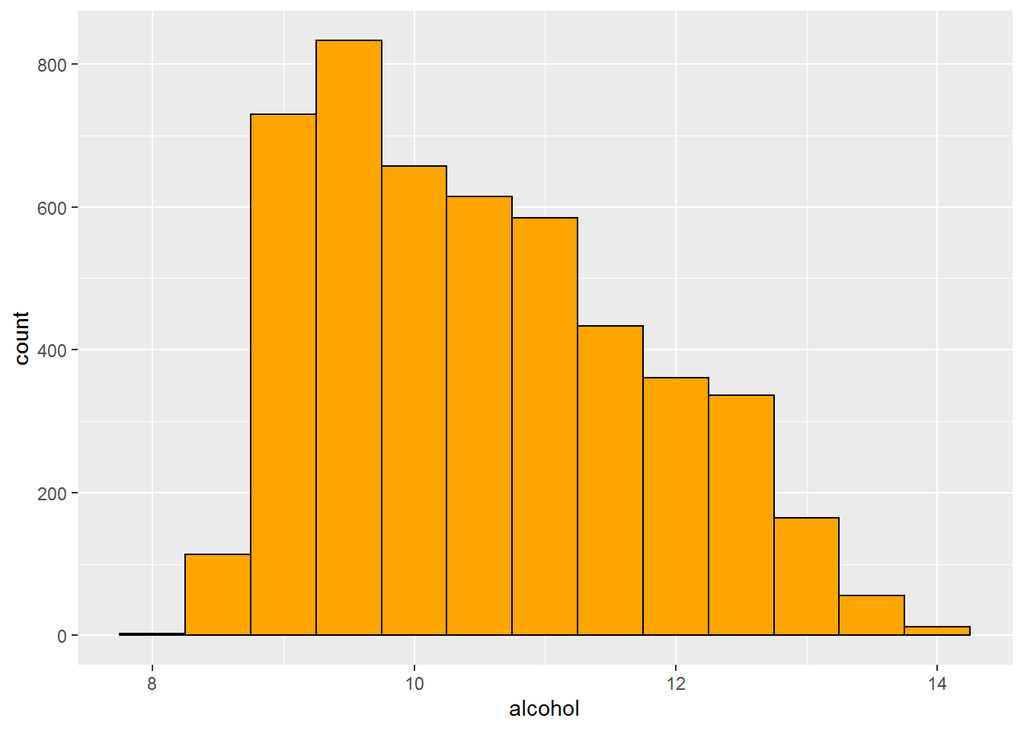

```
##    Min. 1st Qu.  Median    Mean 3rd Qu.    Max.
##    8.00    9.50   10.40   10.51   11.40   14.20
```

The mean alcohol level on the white wines is about 10.5 but some have much higher levels. The histogram is positively skewed. What other properties do the wines with high alcohol content have?

```
##         X fixed.acidity volatile.acidity citric.acid residual.sugar chlorides
## 3919 3919           6.4            0.350        0.28            1.6     0.037
## 4504 4504           5.8            0.610        0.01            8.4     0.041
## 1100 1100           5.8            0.290        0.21            2.6     0.025
## 2946 2946           4.9            0.330        0.31            1.2     0.016
## 3151 3151           5.8            0.390        0.47            7.5     0.027
## 3905 3905           5.0            0.455        0.18            1.9     0.036
##      free.sulfur.dioxide total.sulfur.dioxide density   pH sulphates alcohol
## 3919                  31                  113 0.98779 3.12      0.40   14.20
## 4504                  31                  104 0.99090 3.26      0.72   14.05
## 1100                  12                  120 0.98940 3.39      0.79   14.00
## 2946                  39                  150 0.98713 3.33      0.59   14.00
## 3151                  12                   88 0.99070 3.38      0.45   14.00
## 3905                  33                  106 0.98746 3.21      0.83   14.00
##      quality
## 3919       7
## 4504       7
## 1100       7
## 2946       8
## 3151       6
## 3905       7
```

It looks like they are mostly above average quality

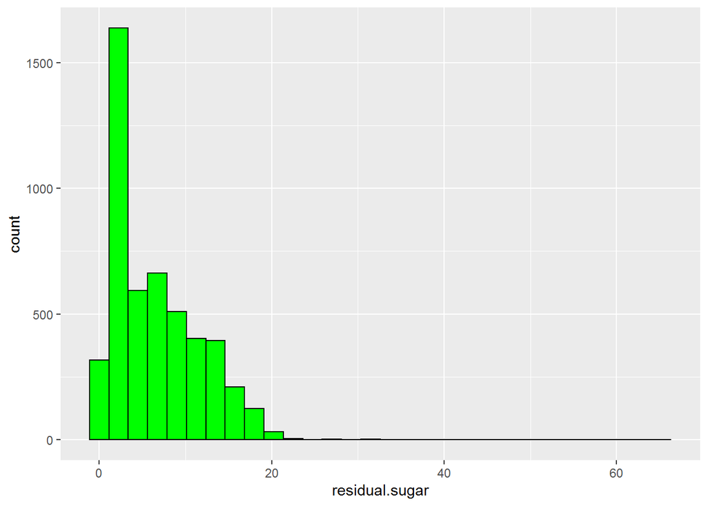

```
##    Min. 1st Qu.  Median    Mean 3rd Qu.    Max.
##   0.600   1.700   5.200   6.391   9.900  65.800
```

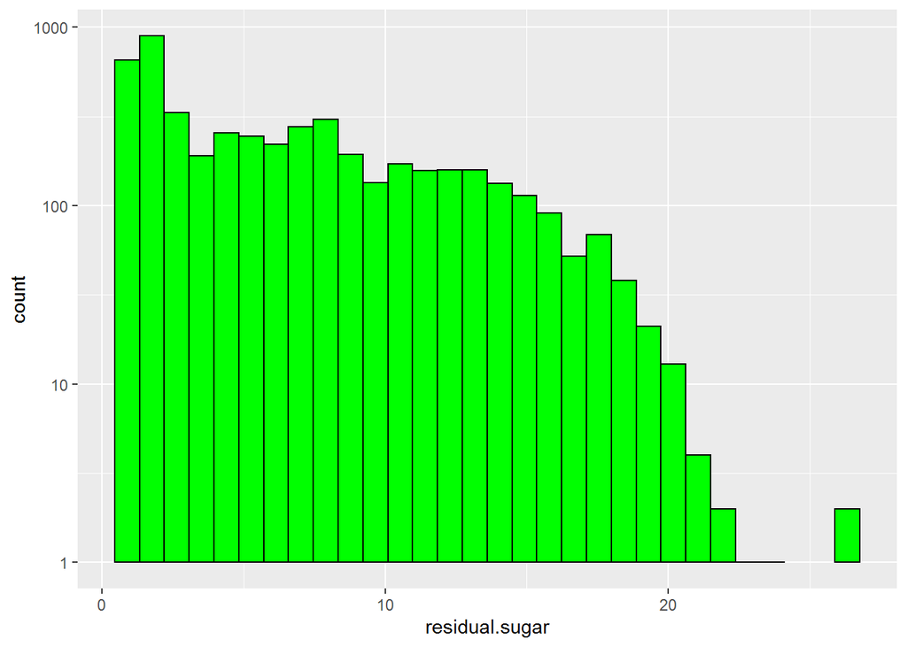

Here I discarded the measurements above 30 and adjusted the Y scale with log10 to get a more normal visualization. Apparently most white wines are low on sugar but some are really high.

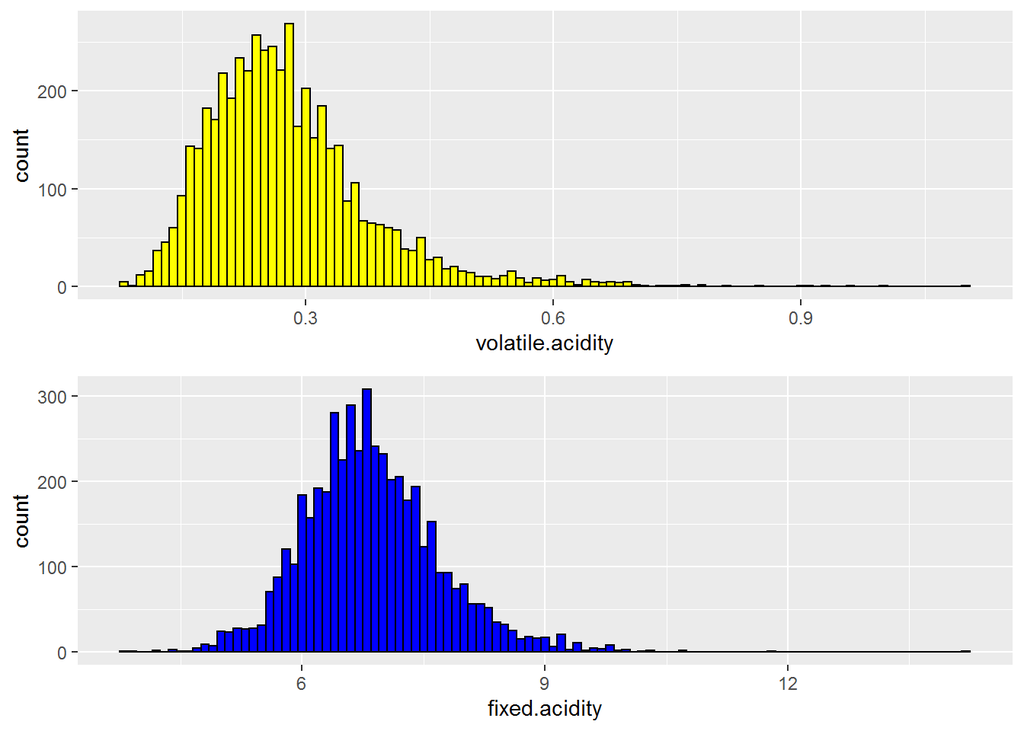

Both the volatile acidity and the fixed acidity give us similar distributions. I wonder if they have a relationship. I’ll have to study this more later.

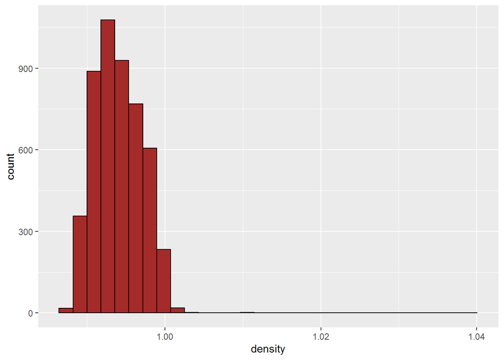

```
##    Min. 1st Qu.  Median    Mean 3rd Qu.    Max.
##  0.9871  0.9917  0.9937  0.9940  0.9961  1.0390
```

Density gives us a normal looking distribution with a couple outliers. I wanted to see what the properties the outliers have.

```
##         X fixed.acidity volatile.acidity citric.acid residual.sugar chlorides
## 2782 2782           7.8            0.965        0.60          65.80     0.074
## 1654 1654           7.9            0.330        0.28          31.60     0.053
## 1664 1664           7.9            0.330        0.28          31.60     0.053
## 3620 3620           6.8            0.450        0.28          26.05     0.031
## 3624 3624           6.8            0.450        0.28          26.05     0.031
## 2335 2335           7.5            0.230        0.35          17.80     0.058
##      free.sulfur.dioxide total.sulfur.dioxide density   pH sulphates alcohol
## 2782                   8                  160 1.03898 3.39      0.69    11.7
## 1654                  35                  176 1.01030 3.15      0.38     8.8
## 1664                  35                  176 1.01030 3.15      0.38     8.8
## 3620                  27                  122 1.00295 3.06      0.42    10.6
## 3624                  27                  122 1.00295 3.06      0.42    10.6
## 2335                 128                  212 1.00241 3.44      0.43     8.9
##      quality
## 2782       6
## 1654       6
## 1664       6
## 3620       6
## 3624       6
## 2335       5
```

They all have high levels of residual sugar. Looks like there may be a relationship.

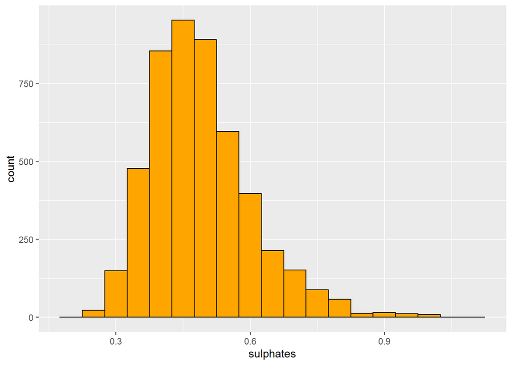

Sulphates give us a fairly normal distribution with a long tail.

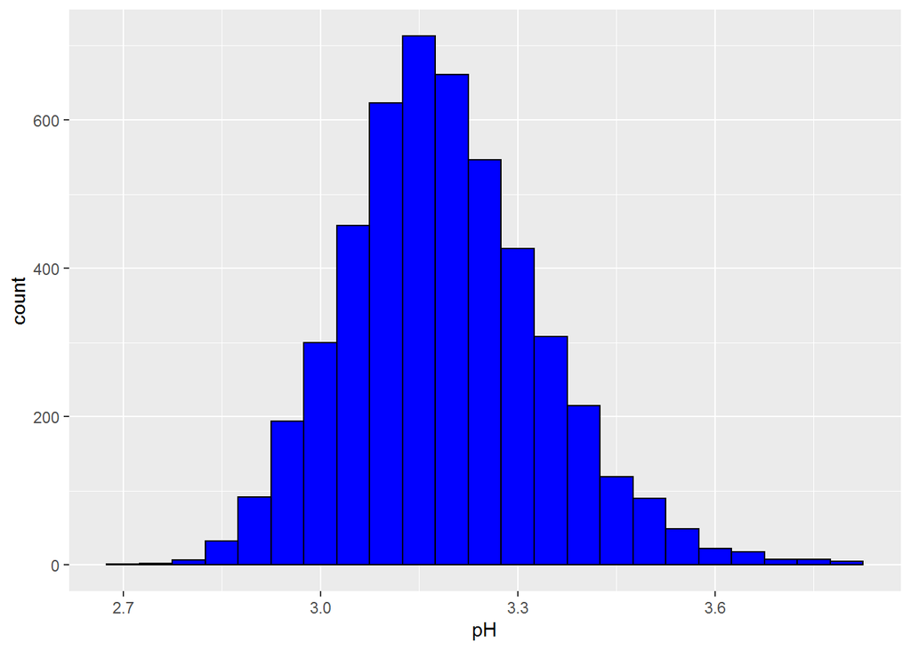

When I looked at the pH data, I got this very normal looking histogram.

# Univariate Analysis

### What is the structure of your dataset?

The data consists of 4898 rows and 12 features:

1. fixed acidity (tartaric acid - g / dm^3)
2. volatile acidity (acetic acid - g / dm^3)
3. citric acid (g / dm^3)
4. residual sugar (g / dm^3)
5. chlorides (sodium chloride - g / dm^3
6. free sulfur dioxide (mg / dm^3)
7. total sulfur dioxide (mg / dm^3)
8. density (g / cm^3)
9. pH
10. sulphates (potassium sulphate - g / dm3)
11. alcohol (% by volume)
12. quality (score between 0 and 10)

### What is/are the main feature(s) of interest in your dataset?

Quality is the main feature of the data. It has simple 1-10 rating system. I plan on analyzing the other 11 columns to see how they affect quality level.

### What other features in the dataset do you think will help support your investigation into your feature(s) of interest.

I think residual sugar levels and alcohol levels will play a big role. I also can see where having high levels of some characteristics like sulfates and acidity might affect the quality level negatively.

### Did you create any new variables from existing variables in the dataset?

No, the measurements given were very conventional.

### Of the features you investigated, were there any unusual distributions? Did you perform any operations on the data to tidy, adjust, or change the form of the data? If so, why did you do this?

# Bivariate Plots Section

```
##                          X fixed.acidity volatile.acidity citric.acid
## X                     1.00         -0.26             0.00       -0.15
## fixed.acidity        -0.26          1.00            -0.02        0.29
## volatile.acidity      0.00         -0.02             1.00       -0.15
## citric.acid          -0.15          0.29            -0.15        1.00
## residual.sugar        0.01          0.09             0.06        0.09
## chlorides            -0.05          0.02             0.07        0.11
## free.sulfur.dioxide  -0.01         -0.05            -0.10        0.09
## total.sulfur.dioxide -0.16          0.09             0.09        0.12
## density              -0.19          0.27             0.03        0.15
## pH                   -0.12         -0.43            -0.03       -0.16
## sulphates             0.01         -0.02            -0.04        0.06
## alcohol               0.21         -0.12             0.07       -0.08
## quality               0.04         -0.11            -0.19       -0.01
##                      residual.sugar chlorides free.sulfur.dioxide
## X                              0.01     -0.05               -0.01
## fixed.acidity                  0.09      0.02               -0.05
## volatile.acidity               0.06      0.07               -0.10
## citric.acid                    0.09      0.11                0.09
## residual.sugar                 1.00      0.09                0.30
## chlorides                      0.09      1.00                0.10
## free.sulfur.dioxide            0.30      0.10                1.00
## total.sulfur.dioxide           0.40      0.20                0.62
## density                        0.84      0.26                0.29
## pH                            -0.19     -0.09                0.00
## sulphates                     -0.03      0.02                0.06
## alcohol                       -0.45     -0.36               -0.25
## quality                       -0.10     -0.21                0.01
##                      total.sulfur.dioxide density    pH sulphates alcohol
## X                                   -0.16   -0.19 -0.12      0.01    0.21
## fixed.acidity                        0.09    0.27 -0.43     -0.02   -0.12
## volatile.acidity                     0.09    0.03 -0.03     -0.04    0.07
## citric.acid                          0.12    0.15 -0.16      0.06   -0.08
## residual.sugar                       0.40    0.84 -0.19     -0.03   -0.45
## chlorides                            0.20    0.26 -0.09      0.02   -0.36
## free.sulfur.dioxide                  0.62    0.29  0.00      0.06   -0.25
## total.sulfur.dioxide                 1.00    0.53  0.00      0.13   -0.45
## density                              0.53    1.00 -0.09      0.07   -0.78
## pH                                   0.00   -0.09  1.00      0.16    0.12
## sulphates                            0.13    0.07  0.16      1.00   -0.02
## alcohol                             -0.45   -0.78  0.12     -0.02    1.00
## quality                             -0.17   -0.31  0.10      0.05    0.44
##                      quality
## X                       0.04
## fixed.acidity          -0.11
## volatile.acidity       -0.19
## citric.acid            -0.01
## residual.sugar         -0.10
## chlorides              -0.21
## free.sulfur.dioxide     0.01
## total.sulfur.dioxide   -0.17
## density                -0.31
## pH                      0.10
## sulphates               0.05
## alcohol                 0.44
## quality                 1.00
```

Looking at the correlation table, there are a few things that stand out. Density strongly correlates with residual sugar and alcohol. Free sulfur dioxide strongly correlates with total sulfur dioxide. Quality, our most important feature, most strongly correlates with alcohol content.

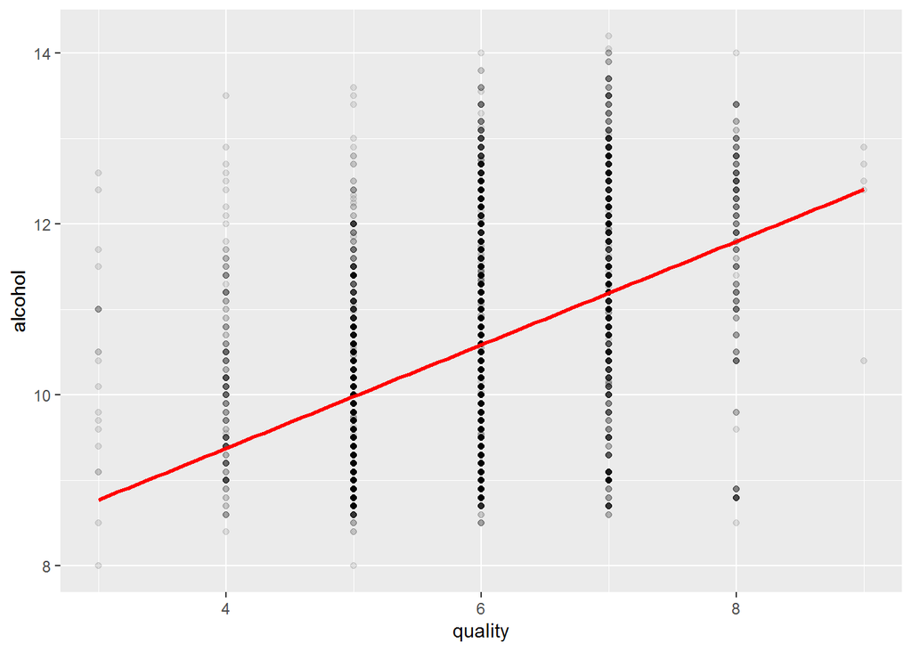

Here we can see the relationship between quality and alcohol content. There are few white wines with a high rating that are low alcohol. The red line is the line of regression.

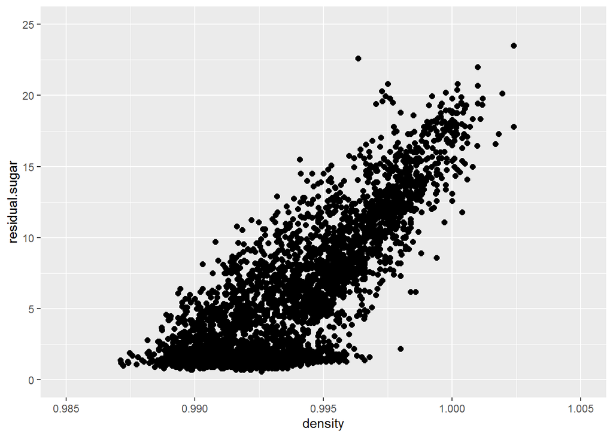

Looking at this scatter plot, it appears that having a high sugar content makes for a more dense wine.

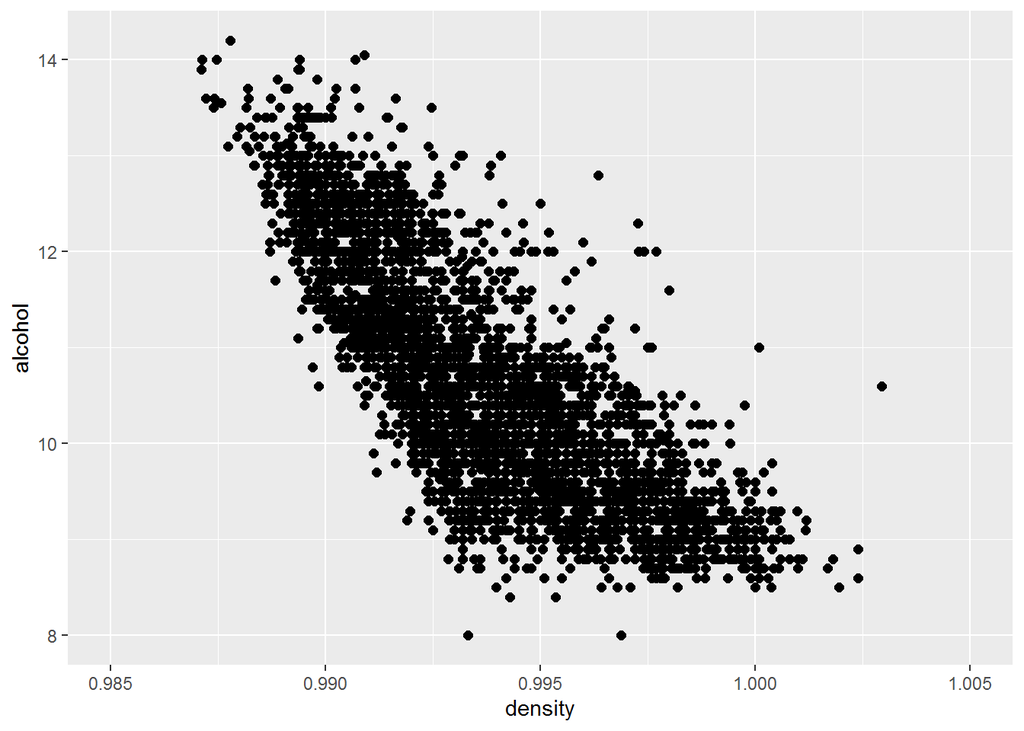

In this scatter plot, we see that the higher the alcohol content, the lower the density.

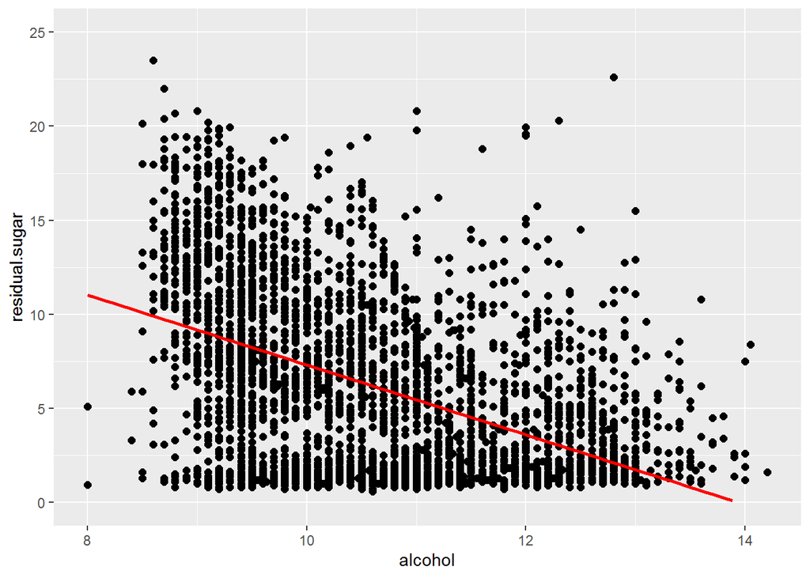

As I suspected guessed, alcohol and residual sugar are inversely correlated. The red line is the line of regression.

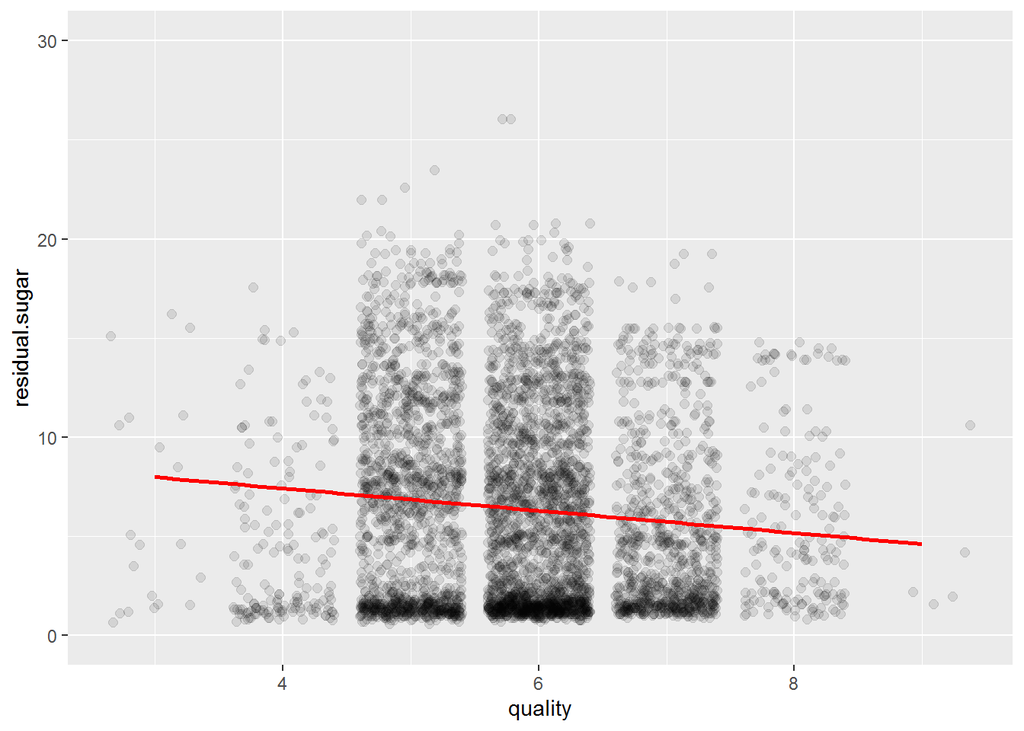

I used jitter and alpha to show that as expected, there are fewer high quality white wines with high residual sugar. However, there are some white wines with high residual sugar. The red line is the line of regression.

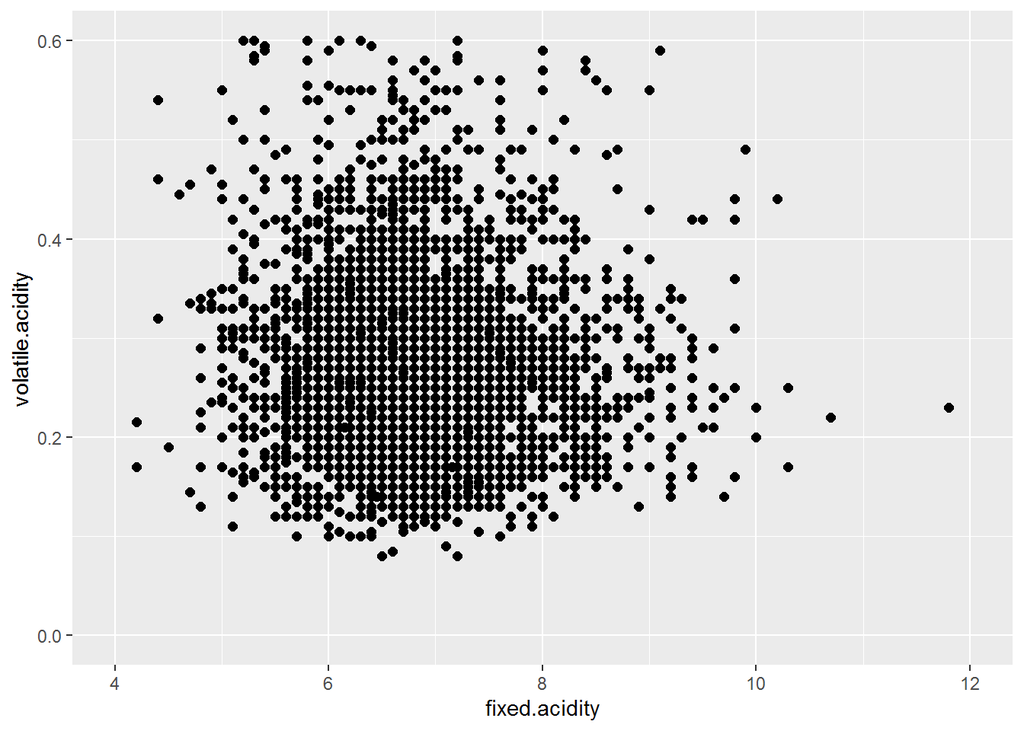

This one surprised me. Although they have similar histogram plots, there is no obvious relationship between fixed acidity and volatile acidity.

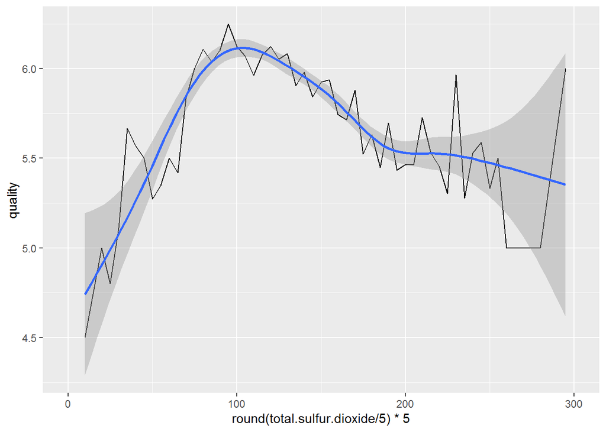

I wondered if some factors had an ideal range of values where the quality of the wine would be the highest. Here I sorted total sulfur dioxide values into buckets and plotted the conditional means of the quality factor. As you can see, the sweet spot for total sulfur dioxide is just around 100.

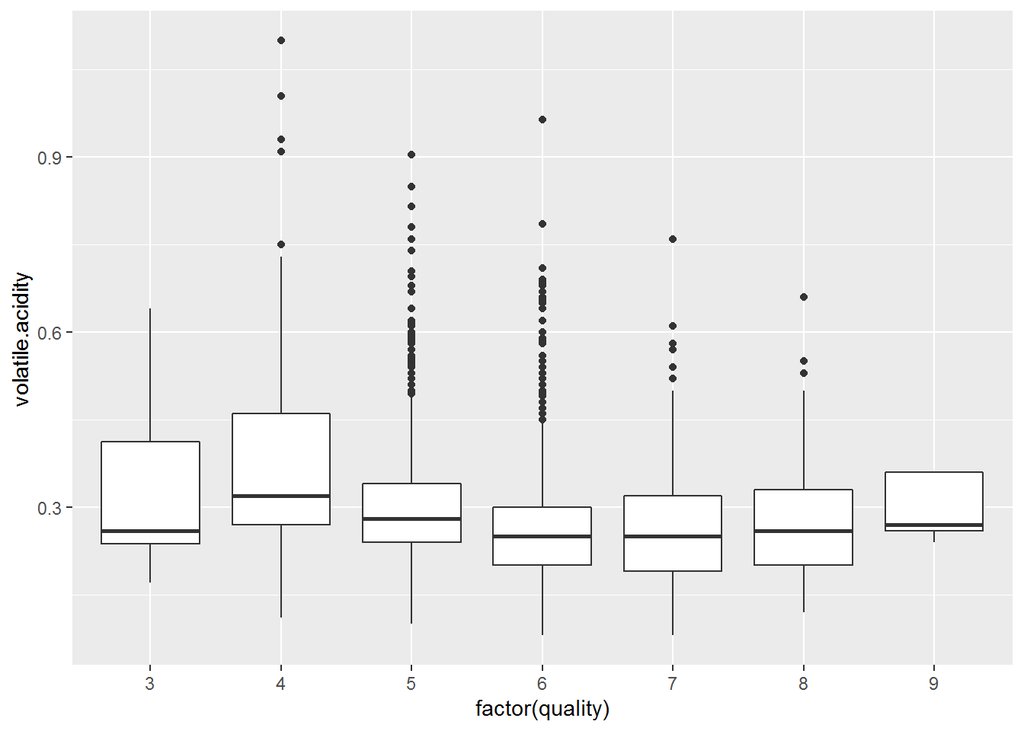

In the description of the data, it says that high levels of volatile acidity would lead to a more vinegar like taste. This box plot shows that high levels of it are definitely less desirable in terms of quality.

# Bivariate Analysis

### Talk about some of the relationships you observed in this part of the investigation. How did the feature(s) of interest vary with other features in the dataset?

Quality has a strongly correlated relationship to alcohol. Many of other factors were inversely correlated to quality indicating that you wouldn’t want their levels to be too high. I found that total.sulfur.dioxide had a range where it was best.

### Did you observe any interesting relationships between the other features (not the main feature(s) of interest)?

The relationships between residual sugar, alcohol, and density were interesting. Alcohol is less dense than water while adding sugar to water adds density. During the fermentation process, sugar is converted to alcohol, thus the inverted correlation of alcohol to residual sugar.

### What was the strongest relationship you found?

The relationship of residual sugar to density was most strongly correlated.

# Multivariate Plots Section

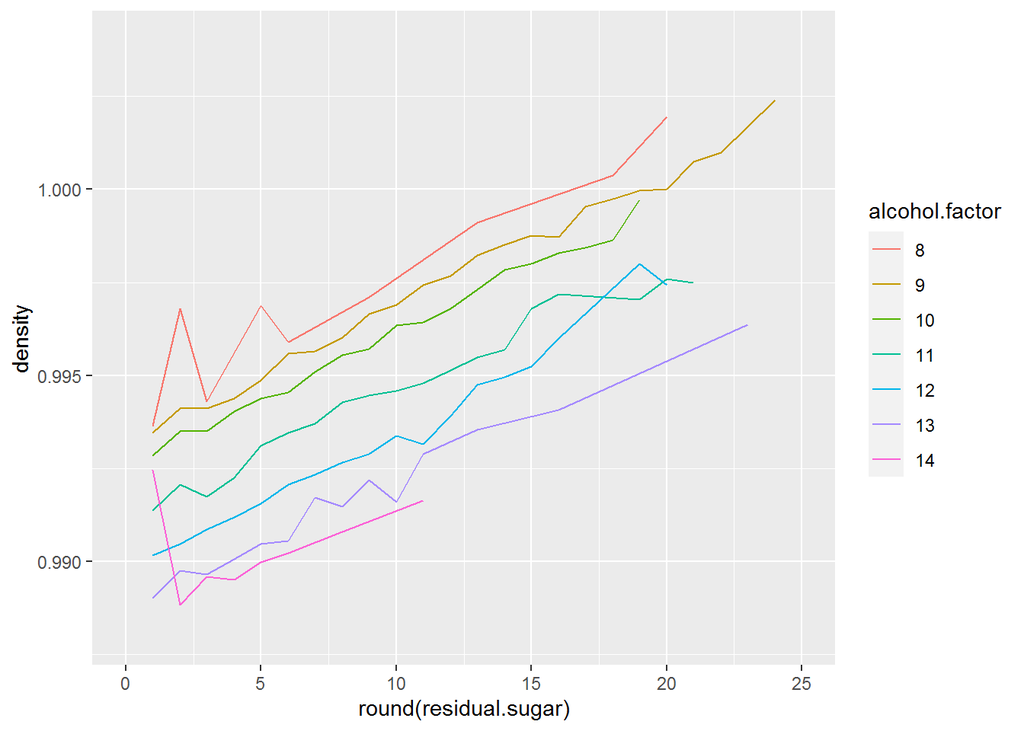

In this plot, I showed the relationship between different levels of alcohol with residual sugar and density. The lines were noisy, so I rounded alcohol to the nearest whole number and made it into a factor. I also rounded residual sugar in order to get smoother lines.

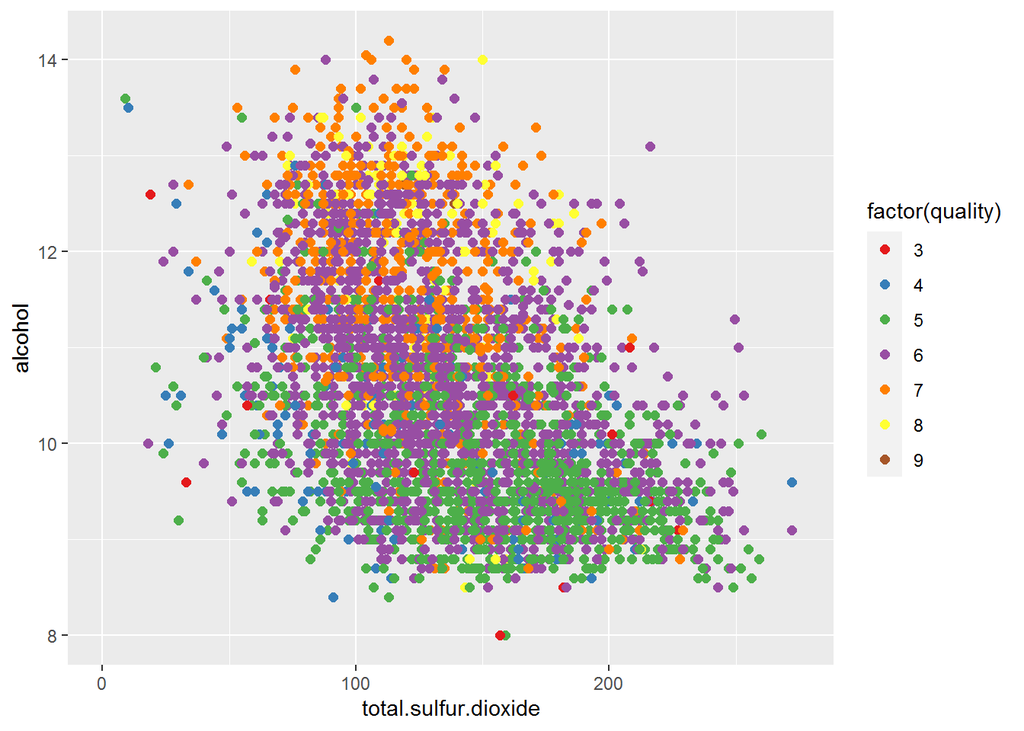

This scatter plot shows the relationship between total sulfur dioxide and alcohol. Quality is the third factor. It shows that higher quality wines have higher alcohol while lower ones have higher total sulfur dioxide.

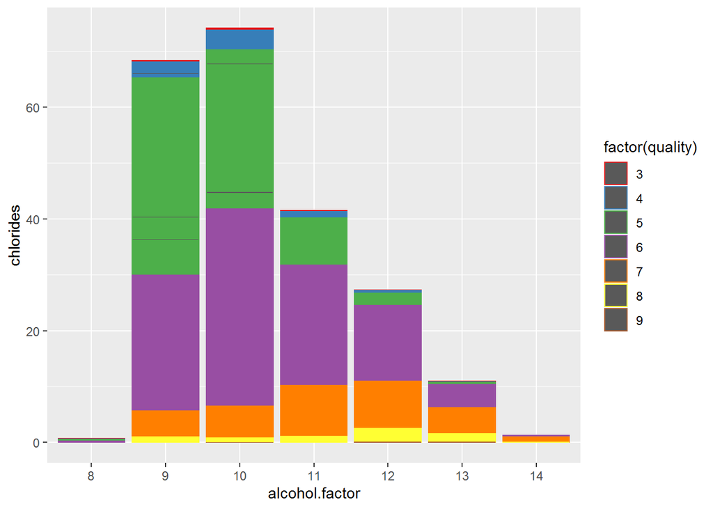

This bar graph shows that wines with higher chlorides generally had lower alcohol percentage. It also shows the levels of quality.

# Multivariate Analysis

### Talk about some of the relationships you observed in this part of the investigation. Were there features that strengthened each other in terms of looking at your feature(s) of interest?

I was able to further study the relationship between residual sugar, alcohol, and density. Most wines with higher levels of alcohol appear to have less sugar and are less dense.

### Were there any interesting or surprising interactions between features?

Surprisingly wines lower in alcohol were saltier or higher in chlorides and lower in quality.

### OPTIONAL: Did you create any models with your dataset? Discuss the strengths and limitations of your model.

I felt that modeling the data was a little beyond the scope of the material. Some of the factors had a middle range where levels were ideal.

# Final Plots and Summary

### Plot One

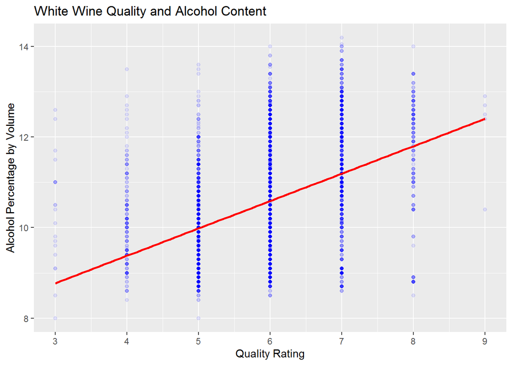

### Description One

In this visualization, I show that the quality rating of white wines is strongly correlated with alcohol content. Because quality is our key factor, it is important to know this correlation. I used alpha to add some transparency to make it easier to see the less dense areas. I also added a line of regression to clearly show the relationship.

### Plot Two

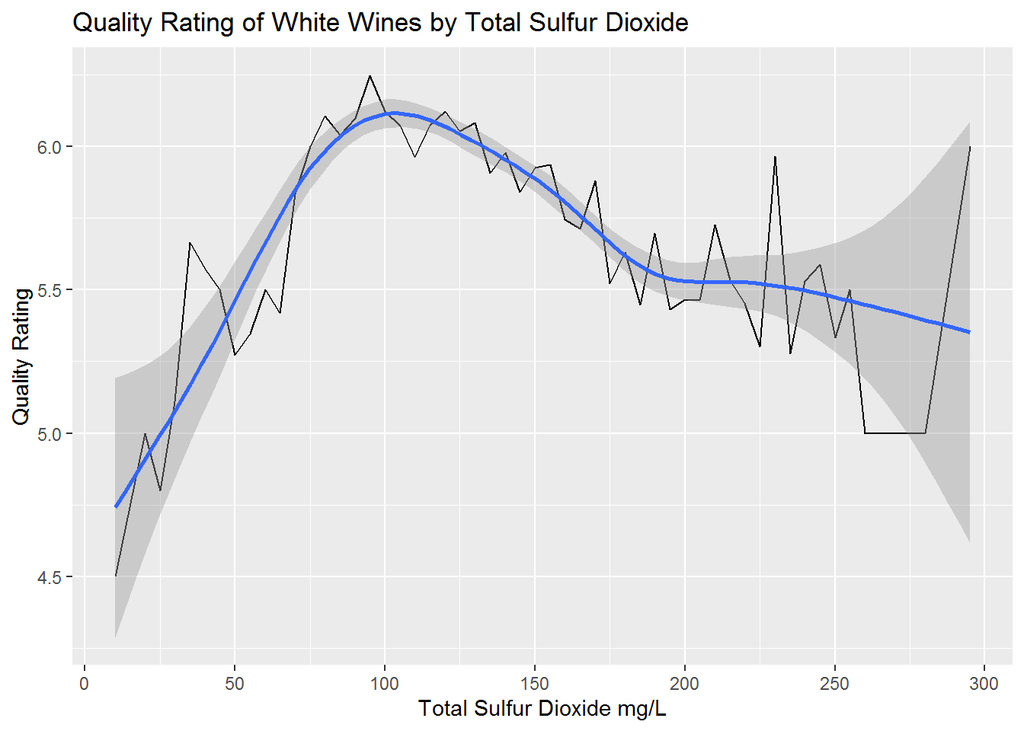

### Description Two

Here I wanted to show that some factors have middle range where the quality rating would be highest. I chose total sulfur dioxide because I suspected at some level, the taste of sulfur would have an undesirable effect on quality. I sorted the wines into bins by the total sulfur dioxide factor. Next I plotted a line graph by plotting the conditional means of the quality factor for each bin. I had a lot of noise, so I cleaned it by making fewer points by dividing and rounding the x factor. I trimmed the x axis at 300 because of some outliers. Lastly I used Geom_Smooth to show a nice smooth curve.

### Plot Three

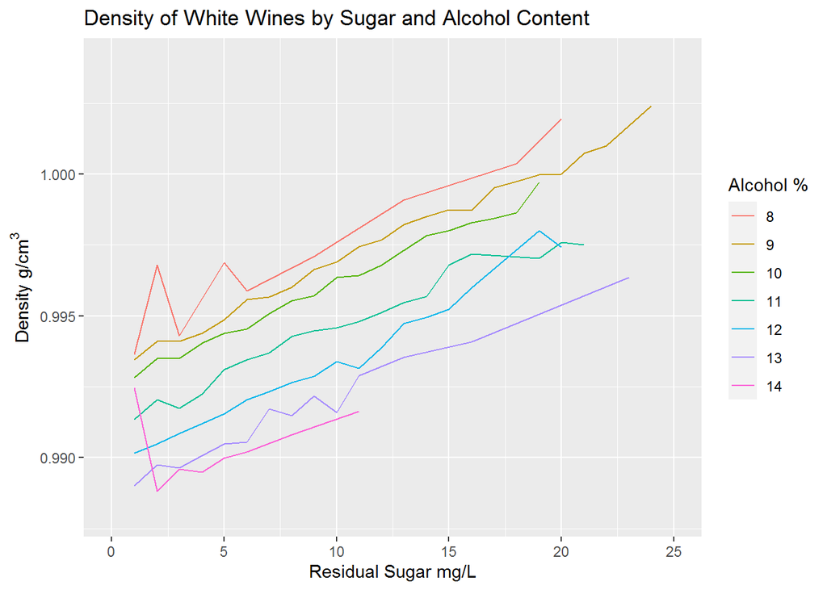

### Description Three

I wanted to show the three-way relationship between residual sugar, alcohol, and density. I rounded the alcohol levels and made a factor. I plotted a line graph that gives a colored line for each alcohol level. I reduced the noise by rounding the residual sugar factor. Finally I trimmed the x and y axes to get a closer look.

# Reflection

The white wine data set that I used was pretty large, nearly 5000 observations. It gave me a good variety of data with a huge amount of average rated wines and many outliers. The biggest flaw I found was in the the main factor, quality. It is based on a rating from 1 to 10 by a median of just three evaluations by wine experts. That is really small number and no other information about the wine experts is given.

It was interesting to find that different chemical components had relationships with the density of the wine. I also found that some factors have a sweet spot where their levels were optimal for higher quality. There is a clear relationship between alcohol level and quality.

I struggled to find relationships between many of the factors. They seemed irrelevant to my analysis. They contributed very little, if not at all, to the main Quality factor. Overall, I think I was successful at discovering the factors that made the biggest difference.

It would be interesting to contrast the white wines with the sister data set of red wines. I’m curious to see the chemical differences there are between them. Would red wines generally be higher in density because they are sweeter?